# Exercise_05_Challenge_1

SLCornett

2/21/2022

```r
library(tidyverse)
```

```r
library(mosaic)
library(dplyr)
library(ggplot2)
```

1. Using the {tidyverse} read_csv() function, load the “IMDB-movies.csv” dataset from this URL as a “tibble” named d

```r
f1 <- "https://raw.githubusercontent.com/difiore/ada-2022-datasets/main/IMDB-movies.csv"
d <- read_csv(f1, col_names = TRUE)
df<- d %>% filter(startYear %in% 1920:1979, runtimeMinutes %in% 60:180) %>%
  mutate("decade"=case_when(startYear %in% 1920:1929~"20s",
                            startYear %in% 1930:1939~"30s",
                            startYear %in% 1940:1949~"40s",
                            startYear %in% 1950:1959~"50s",
                            startYear %in% 1960:1969~"60s",
                            startYear %in% 1970:1979~"70s"
                            )
         )
print(df)
```

```
## # A tibble: 5,651 × 11
##    tconst   titleType primaryTitle startYear runtimeMinutes genres averageRating
##    <chr>    <chr>     <chr>            <dbl>          <dbl> <chr>          <dbl>
##  1 tt00103… movie     The Cabinet…      1920             76 Fanta…           8.1
##  2 tt00110… movie     Leaves From…      1920            167 Drama            6.7
##  3 tt00111… movie     Dr. Jekyll …      1920             82 Drama…           7
##  4 tt00112… movie     The Golem         1920             76 Fanta…           7.2
##  5 tt00113… movie     The Last of…      1920             73 Actio…           6.7
##  6 tt00114… movie     The Mark of…      1920            107 Adven…           7.1
##  7 tt00115… movie     The Penalty       1920             90 Crime…           7.4
##  8 tt00116… movie     The Saphead       1920             77 Comedy           6.2
##  9 tt00118… movie     Way Down Ea…      1920            145 Drama…           7.4
## 10 tt00118… movie     Why Change …      1920             90 Comed…           6.7
## # … with 5,641 more rows, and 4 more variables: numVotes <dbl>, nconst <chr>,
## #   director <chr>, decade <chr>
```

A: Table has 5,651 items . 2. Use {ggplot2} (which is part of {tidyverse}) to plot histograms of the distribution of runtimeMinutes for each decade

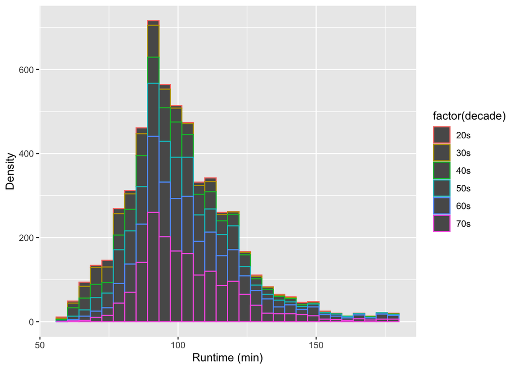

```r
# boxplot(runtimeMinutes ~ startYear, data=df, xlab="Decade", ylab="runtime (min)") #test that decade works in general, it does
p <- ggplot(data = df)  #object built (in theory) -> don't need aes(x, y) here because R gets confused and angry
p <- p + xlab("Runtime (min)") + ylab("Density") #data labels
#p <- p + geom_point(na.rm=TRUE) # makes a "scatterplot" that's more a bar graph of dots
#p <- p + histogram(~ decades, data = df$runtimeMinutes, xlab = "Runtime (min)") #incompatible and also just doesn't work with ggplot2, or on its own
p<- p + geom_histogram(aes(x=runtimeMinutes,#no need y= or stat=identity
                                    color=factor(decade),
                                    binwidth = 30,
                                    )) #x, y, alpha, color, fill, linetype, size, weight
p
```

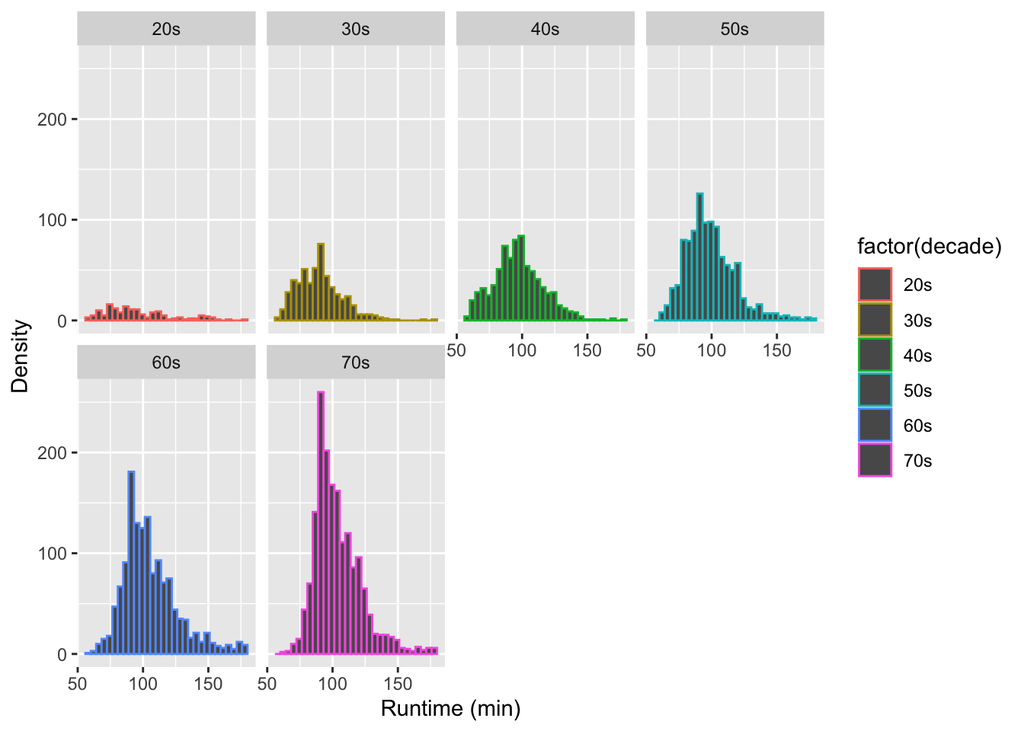

```r
p <- p + facet_wrap(~ decade, ncol=4) # wrap data "by" decade into 4 columns
p
```

3. Use a one-line statement to calculate the population mean and population standard deviation in *runtimeMinutes* for each decade and save the results in a new dataframe called “results”.

```r
#actual population
results <- group_by(df, decade)%>%
  summarise(
    pop_mean=mean(runtimeMinutes, na.rn=TRUE), #population mean
    pop_sd=sd(runtimeMinutes, na.rm=TRUE), #population sd
    pop_se=pop_sd/sqrt(100) #se
    )
print(results) # population mean, standard deviation, standard error
```

```
## # A tibble: 6 × 4
##   decade pop_mean pop_sd pop_se
##   <chr>     <dbl>  <dbl>  <dbl>
## 1 20s        96.3   26.2   2.62
## 2 30s        90.3   17.3   1.73
## 3 40s        97.2   19.1   1.91
## 4 50s        98.9   19.2   1.92
## 5 60s       106.    21.2   2.12
## 6 70s       104.    18.0   1.80
```

4-5. [A] Draw a single sample of 100 movies, without replacement, from each decade and calculate the single sample mean and single sample standard deviation in *runtimeMinutes* for each *decade*. Recall that your single sample mean for each decade is an estimate of the population mean for each decade. [B] Calculate for each decade the standard error around your estimate of the population mean runtimeMinutes based on the standard deviation and sample size (n=100 movies) of your single sample.

```r
x <- group_by(df, decade) %>%
  sample_n(100, replace = FALSE) %>% #no replacement
  summarise(
    samp_mean=mean(runtimeMinutes, na.rn=TRUE), #sample mean
    samp_sd=sd(runtimeMinutes, na.rm=TRUE), #sample sd
    samp_se=samp_sd/sqrt(100) #sample standard error
    ) # pull single sample from 100 movies for each decade
x #prints the results
```

```
## # A tibble: 6 × 4
##   decade samp_mean samp_sd samp_se
##   <chr>      <dbl>   <dbl>   <dbl>
## 1 20s         98.4    28.0    2.80
## 2 30s         88.7    15.8    1.58
## 3 40s         94.2    17.6    1.76
## 4 50s         96.4    20.4    2.04
## 5 60s        103.     20.4    2.04
## 6 70s        102.     17.2    1.72
```

6. Compare these estimates to the actual population mean *runtimeMinutes* for each decade and to the calculated SE in the population mean for samples of size 100 based on the population standard deviation for each decade.

```r
#actual population = results
#SE calculation pop of sample of 100 = x
comparison_1 <- left_join(x, results, by = "decade") #merge also works (module 10)
print(comparison_1) #prints the left-joined tables of x and results
```

```
## # A tibble: 6 × 7
##   decade samp_mean samp_sd samp_se pop_mean pop_sd pop_se
##   <chr>      <dbl>   <dbl>   <dbl>    <dbl>  <dbl>  <dbl>
## 1 20s         98.4    28.0    2.80     96.3   26.2   2.62
## 2 30s         88.7    15.8    1.58     90.3   17.3   1.73
## 3 40s         94.2    17.6    1.76     97.2   19.1   1.91
## 4 50s         96.4    20.4    2.04     98.9   19.2   1.92
## 5 60s        103.     20.4    2.04    106.    21.2   2.12
## 6 70s        102.     17.2    1.72    104.    18.0   1.80
```

```r
#also works: Merge {dyplyr}
#comparison_1 <- merge(x, results, by = "decade")
#print(comparison_x_results)
```

7. Generate a sampling distribution of mean *runtimeMinutes* for each decade by [a] drawing 1000 samples of 100 movies from each decade and, for each sample, [b] calculating the mean *runtimeMinutes* and the standard deviation in *runtimeMinutes* for each decade. -> Use either the do(reps) * formulation from {mosaic}, the rerun() function from {purrr}, or the rep_sample_n() workflow from {infer} to generate your these sampling distributions (see Module 12)

```r
#runtimeMinutes sampling distribution (samp_dist = s from assignment)
#[a]
reps<- 1000 # draw 1000 samples
n <- 100 # each sample is 100 movies
#[b]
samp_dist<-do(reps) * sample_n(group_by(df, decade),
                              n, replace=FALSE) %>% #group by decade to sample
                              group_by(decade) %>%  # group by sample in results
                              summarise(
                                samp_dist_mean = mean(~runtimeMinutes, na.rm=TRUE), #sampling distrib mean
                                samp_dist_sd = sd(~runtimeMinutes, na.rm=TRUE)
                                ) #sampling distrib sd
samp_dist #print s
```

```
## # A tibble: 6,000 × 5
##    decade samp_dist_mean samp_dist_sd  .row .index
##    <chr>           <dbl>        <dbl> <int>  <dbl>
##  1 20s              99.3         27.8     1      1
##  2 30s              93.2         19.1     2      1
##  3 40s              97.5         18.8     3      1
##  4 50s              96.5         17.3     4      1
##  5 60s             103.          24.6     5      1
##  6 70s             102.          15.4     6      1
##  7 20s              96.8         26.2     1      2
##  8 30s              91.4         16.9     2      2
##  9 40s              95.7         19.4     3      2
## 10 50s              99.2         19.5     4      2
## # … with 5,990 more rows
```

```r
#below seems incorrect, as it re-writes my samp_dist
#generate sampling distribution
#samp_dist <- {do(reps) * sample_n(df, n, replace = FALSE)} %>%
  #group_by(decade, .index) %>%
  #summarise('mean(runtumeMinutes)' = mean(runtimeMinutes))
```

8. [A] calculate the *MEAN* and the *STANDARD DEVIATION* of the Sampling Distribution of sample means for each decade (the former should be a very good estimate of the population mean, while the latter is another estimate of the standard error in our estimate of the population mean for a particular sample size) and [B] plot a histogram of the sampling distribution for each decade. What shape does it have?

```r
# mean(~ samp_dist_mean, data = samp_dist) #calculates the mean for nothing because it does not work.
#A
samp_distDecMeans <- aggregate(samp_dist_mean~decade, mean, data = samp_dist)
samp_distDecMeans
```

```
##   decade samp_dist_mean
## 1    20s       96.21159
## 2    30s       90.33500
## 3    40s       97.15760
## 4    50s       98.93795
## 5    60s      105.56889
## 6    70s      103.83078
```

```r
samp_distDecSDs <- aggregate(samp_dist$samp_dist_mean, by = list(samp_dist$decade), FUN = sd)
samp_distDecSDs #sd by decade from samp_dist (random sample of 100, 1000 times)
```

```
##   Group.1        x
## 1     20s 1.549279
## 2     30s 1.543925
## 3     40s 1.813850
## 4     50s 1.797789
## 5     60s 1.994644
## 6     70s 1.771312
```

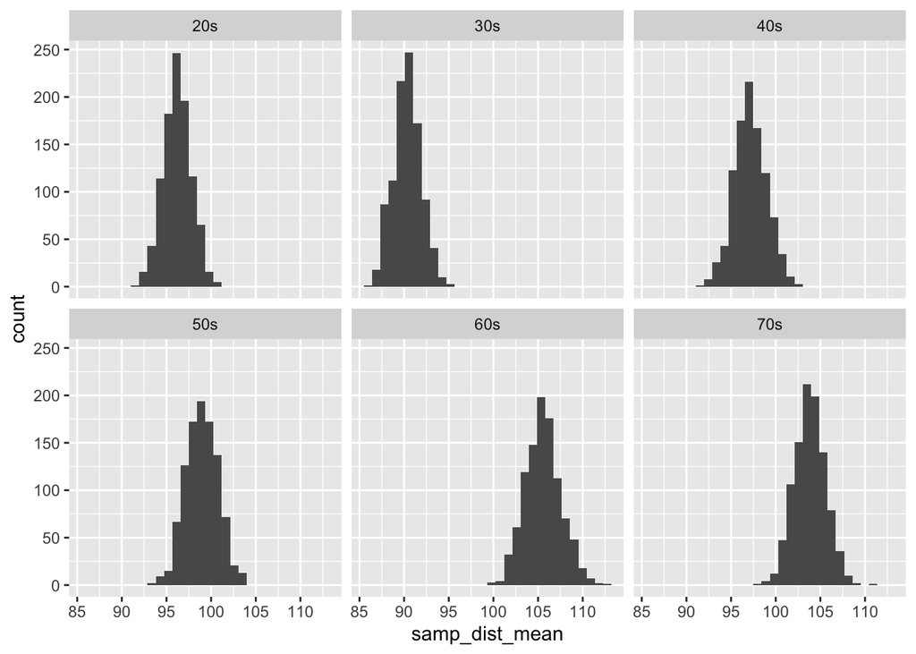

```r
names(samp_distDecSDs)[names(samp_distDecSDs)=="Group.1"]<- "decade" #change column name in samp_dist_DecSDs
names(samp_distDecSDs)[names(samp_distDecSDs)=="x"] <- "samp_dist_sd" #change column name in samp_dist_DecSDs

merge_samp_dist <- left_join(samp_distDecMeans, samp_distDecSDs, by = "decade")

#B
#histogram()
#samp_dist_hist <- ggplot(data = samp_dist, aes("mean_runtimeMinutes"))
#samp_dist_hist <-

samp_dist_hist <- ggplot(data = samp_dist, aes(x = samp_dist_mean)) + geom_histogram() + facet_wrap(~decade) #grey histogram
samp_dist_hist
```

A: normal distribution, shaped like the empire state building.

9. Finally, compare the standard error in *runtimeMinutes* for samples of size 100 from each decade [1] as estimated from your first sample of 100 movies, [2] as calculated from the known population standard deviations for each decade, and [3] as estimated from the sampling distribution of sample means for each decade.

```r
#Notes from Tony 03/03/22:  I think you don't calculate the SE as estimated from the sampling distribution of sample means for each decade correctly, and in line 97, you're directly taking the mean of the runtime of 100,000 movies instead of the mean of 1000 sample means that are each based on 100 movies. in this case, the values are the same (I think), but if sample sizes varied, then the former wouldn't be the same

# n = sample size
SE_20s <- (samp_distDecMeans[1,2])/sqrt(reps)
SE_30s <- (samp_distDecMeans[2,2])/sqrt(reps)
SE_40s <- (samp_distDecMeans[3,2])/sqrt(reps)
SE_50s <- (samp_distDecMeans[4,2])/sqrt(reps)
SE_60s <- (samp_distDecMeans[5,2])/sqrt(reps)
SE_70s <- (samp_distDecMeans[6,2])/sqrt(reps)
decade <- c("20s", "30s", "40s", "50s", "60s", "70s")
samp_distSE <- c(SE_20s, SE_30s, SE_40s, SE_50s, SE_60s, SE_70s)
samp_distSEs <- data.frame(decade, samp_distSE)

comparison_2 <- left_join(comparison_1, samp_distSEs, by = "decade") %>%
  select(decade, pop_se, samp_se, samp_distSE)
comparison_2
```

```
## # A tibble: 6 × 4
##   decade pop_se samp_se samp_distSE
##   <chr>   <dbl>   <dbl>       <dbl>
## 1 20s      2.62    2.80        3.04
## 2 30s      1.73    1.58        2.86
## 3 40s      1.91    1.76        3.07
## 4 50s      1.92    2.04        3.13
## 5 60s      2.12    2.04        3.34
## 6 70s      1.80    1.72        3.28
```